[figure not shown]

En este notebook verás el una posible solución para el problema de despliegue del algoritmo K vecinos más cercanos desarrollado en un ejercicio anterior.

En particular, se cargará una plantilla de proyecto con la base para desplegar y tu objetivo será completar la información faltante.

# Tabla de contenido

1. Cierre del entrenamiento.
2. Clonar el proyecto.
3. Crear cuenta en Streamlit.
4. Conocer la estructura de la aplicación.
5. Finalizar la construcción de la aplicación.
6. Evaluar el producto final.
7. Cierre

# 1. Cierre del entrenamiento.

En el notebook de entrenamiento se realizó todo el proceso de preparación de datos, transformación (escalamiento y reducción de dimensionalidad) y ajuste del modelo.

Sin embargo, el entrenamiento por sí solo no garantiza el despliegue. Para poder utilizar el modelo en una aplicación (por ejemplo, en Streamlit), es necesario persistir el artefacto entrenado, de manera que pueda ser cargado posteriormente sin necesidad de volver a ejecutar todo el proceso de entrenamiento.

En proyectos de Machine Learning es fundamental:

- Conservar el modelo entrenado.
- Conservar los transformadores utilizados (por ejemplo, `StandardScaler`, `PCA`).
- Garantizar compatibilidad de versiones de las librerías utilizadas.

Dado que el proceso fue desarrollado con **scikit-learn**, **pandas**, **numpy** y **matplotlib**, contamos principalmente con dos mecanismos de serialización en Python:

1. **Joblib (joblib)**:
- **Propósito**: El formato `Joblib` está optimizado para serializar objetos grandes de Python, especialmente aquellos que contienen estructuras NumPy, así como modelos de scikit-learn. En el contexto de aprendizaje automático, se utiliza para guardar modelos entrenados, incluyendo sus parámetros internos, transformadores (como StandardScaler y PCA) y pipelines completos. Es especialmente eficiente cuando se trabaja con matrices grandes.
- **Portabilidad**: Puede ser utilizado en diferentes entornos Python siempre que las versiones de scikit-learn y sus dependencias sean compatibles. Es ideal para despliegues dentro del ecosistema Python (por ejemplo, aplicaciones en Streamlit, FastAPI o notebooks). Sin embargo, no está diseñado para interoperabilidad entre diferentes lenguajes.
2. **Pickle (PCKL)**:
- **Propósito**: El formato `Pickle` es un módulo de serialización de Python que se utiliza para guardar y cargar objetos de Python. Puede utilizarse para guardar objetos en general, incluyendo modelos de aprendizaje automático. Sin embargo, no está diseñado específicamente para modelos de aprendizaje automático y no almacena información sobre la arquitectura de un modelo ni su gráfico de cómputo.
- **Portabilidad**: Puede ser utilizado dentro de Python y es adecuado para guardar y cargar objetos de Python, pero no es tan adecuado para la interoperabilidad entre diferentes lenguajes o entornos.

Para complementar el notebook, deberas ir al notebook, entrenar nuevamente e incorporar en las sección final las siguientes instrucciones:

Incluye la libreria `joblib`:

> import joblib

Ahora vamos a importar la información de cada uno de los componentes del proceso, estandarización de los datos, PCA y el mejor modelo:

> joblib.dump(`standard_scaler`, "scaler.joblib")

> joblib.dump(`pca`, "pca.joblib")

> joblib.dump(`mejor_modelo`, "model.joblib")

Recuerda que estamos haciendo uso de los nombres de las variables del entreamiento

# 2. Clonar el proyecto.

Para asegurar los despliegues en la comunidad de `streamlit` requerimos de las siguientes condiciones:

- Repositorio GIT público.
- Cuenta de streamlit (versión community).

Clona la información desde la siguiente dirección [GIT](https://github.com/fcastellanosp/MAIA-4211_202611_MLNS_Deploy) en el repositorio de tu cuenta.

Asegura la dirección `url` de tu repositorio, la vamos a necesitar más adelante.

# 3. Crear cuenta en Streamlit.

Ingresa a streamlit y usa la opción `Create app`:

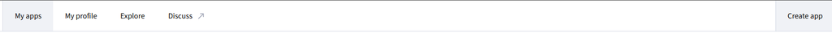

[figure not shown]

Selecciona en `repository` la ruta del repositorio de tu `GitHub`, de la misma forma en `App Url` reemplaza 202x por tu código de estudiante:

[figure not shown]

Ahora vamos a ir a `Advanced settings`, de esta forma vamos a asegurar la versión de python `3.10`:

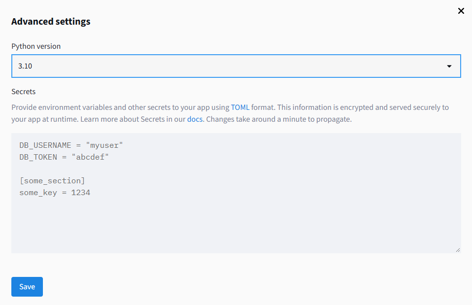

Selecciona la opción `Deploy a public app from GitHub`:

[figure not shown]

# 4. Conocer la estructura de la aplicación.

## 4.1. Configuración del entorno local.

Para este proceso se recomienda hacer uso de una IDE de desarrollo como Visual Studio Code, Pycharm, entre otros.

Debes tener en cuenta las siguientes condiciones:

### 4.1.1. Librerías

En términos generales, siempre deberás tener en cuenta los siguientes elementos:

- Versión de python sobre la cuál será desarrollada la aplicación.
- Librerías sobre la cuál fue desarrollado el modelo.
- Librería(s) para la interfaz gráfica (UI).
- Otras librerías.

En este orden de ideas y para este notebook, para cada una de las anteriores, relacionaremos la información correspondiente:

- Versión de python sobre la cuál será desarrollada la aplicación: `3.10`.
- Librerías sobre la cuál fue desarrollado el modelo: `Scikit-learn`.
- Librería(s) para la interfaz gráfica (UI): `streamlit`.
- Otras librerías: `Ninguna`.

### 4.1.2. Estructura del proyecto.

Vamos a asumir que el nombre que fue clonada la información es: `IMG_Classifier`. Para este ejercicio, usaremos la siguiente estructura:

```
IMG_Classifier/
  resources/
    batch/
      streamlit.bat
    data/
      test_data.xlsx
    models/
      model.joblib
      pca.joblib
      scaler.joblib
  src/
    ModelController.py
    DataPrePreprocessing.py
  streamlit_app.py
  requirements.txt
```

**TIP**: Tu ambiente podrá estar configurado con un patrón de desarrollo, configuraciones, entre otros que consideres necesarios, deberás asegurar se encuentren en armonía con el despliegue.

Carpeta de recursos.

```
IMG_Classifier/
  resources/
    models/
      model.joblib
      pca.joblib
      scaler.joblib
```

Esta carpeta tendrá como propósito almacenar la información del entrenamiento como la vimos anteriormente.

Ten en cuenta que en la plantilla ya cuentas con esa información.

Archivo de requisitos o requerimientos:

```
IMG_Classifier/
  requirements.txt
```

Archivos de modelamiento en la carpeta de recursos y la clase python encargada de procesar la lógica del modelo:

```
IMG_Classifier/
  resources/
    models/
      model.joblib
      pca.joblib
      scaler.joblib
  src/
    ModelController.py
```

`streamlit_app.py` es el erchivo principal del aplicativo web, desde allí realizaremos los llamados a los componentes de streamlit.

El archivo bat en tu entorno local te ayudará a lanzar el aplicativo:

```
IMG_Classifier/
  resources/
    batch/
      streamlit.bat
  streamlit_app.py
```

Acá puedes conectar la configuración que hicimos en el despliegue de streamlit y el archivo principal del proyecto.

### 4.1.3. Ejecución local.

El archivo bat de la carpeta de recursos hace uso de la variable de entorno `PYTHONPATH` que deberás tener configurada en tu ambiente local, recuerda en este mismo entorno instalar las librerías para tu desarrollo e incluirlas en el listado en el archivo `requirements.txt`

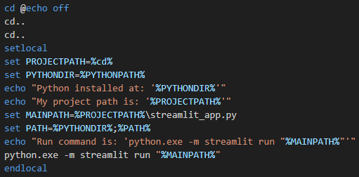

Las instrucciones anteriores asegurarán la identificación de la ruta del proyecto mediante rutas relativas e invocar el comando streamlit para ejecución del aplicativo localmente. Deberás encontrar una línea de comandos similar a la siguiente ilustración:

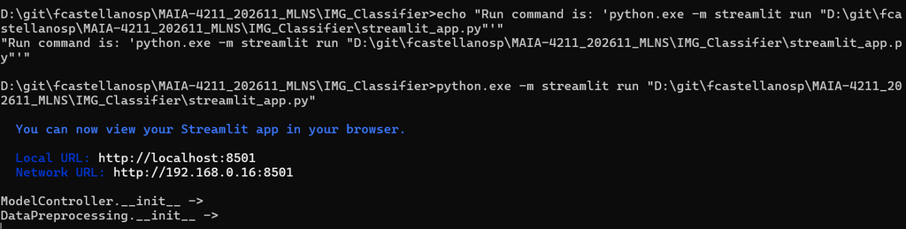

# 5. Finalizar la construcción de la aplicación.

## ¿Qué queremos desplegar?.

Vamos a construir la interfaz con 2 secciones:

Los datos de entrada en formato csv, van acá:

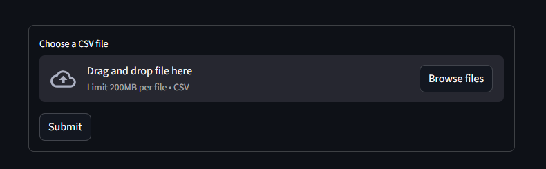

Los resultados se van a visualizar así:

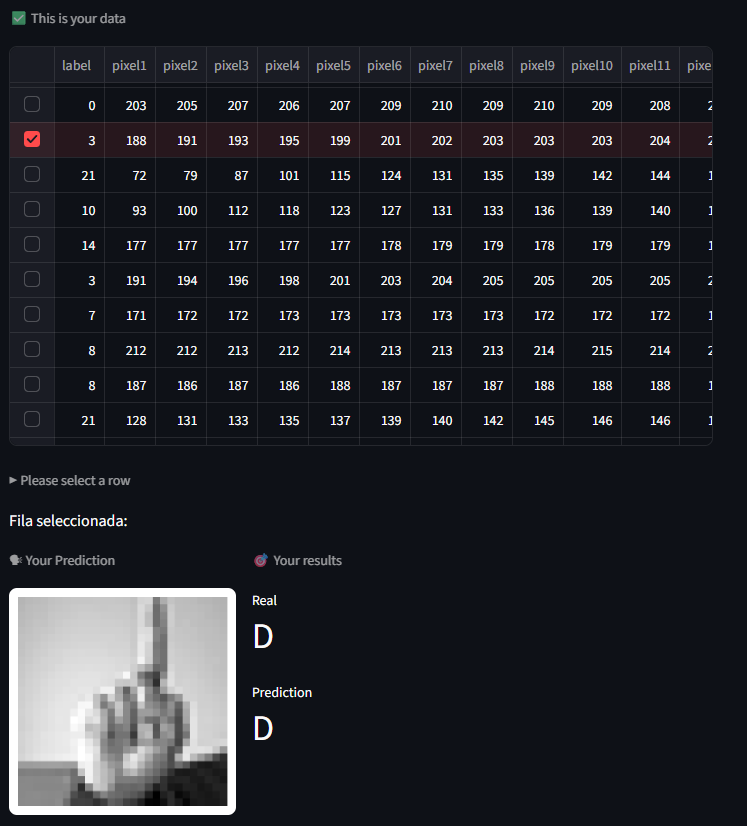

La visualización está compuesta por un dataframe que permite visualizar los datos cargados.

En la sección inferior verás la imagen generada por el modelo y la comparación de los datos que ingresan versus los datos predecidos. La imagen anterior, permite visualizar una predicción correcta, en el caso de una incorrecta se vería de la siguiente forma:

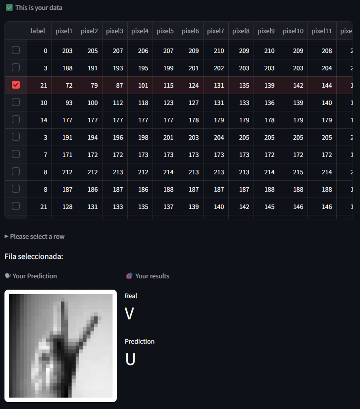

## Manos a la obra.

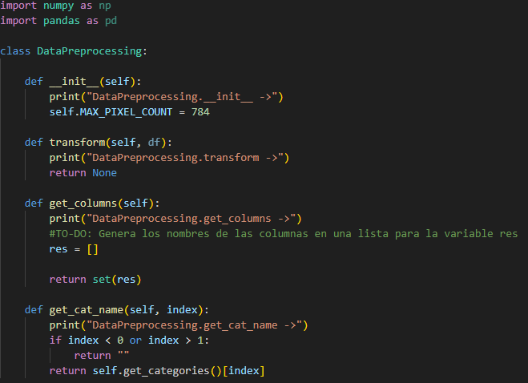

Incorpora la librería joblib y carga los 3 archivos del entrenamiento:

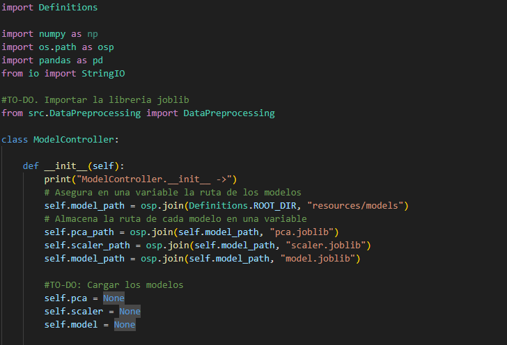

Asegura la predicción del modelo en la clase ModelController:

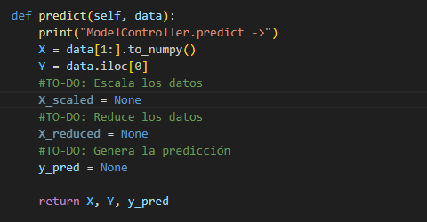

Ahora trabaja en la presentación de la interfaz:

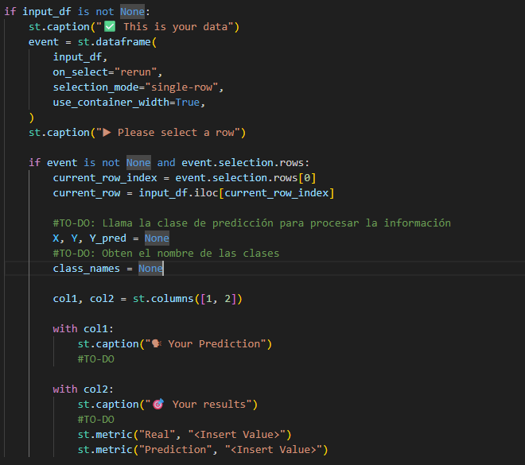

Carga todo el proceso desarrollado a tu GIT para actualizar el despliegue.

# 6. Evaluar el producto final.

Al recargar o redesplegar la aplicación inicialmente debe verse de la siguiente forma:

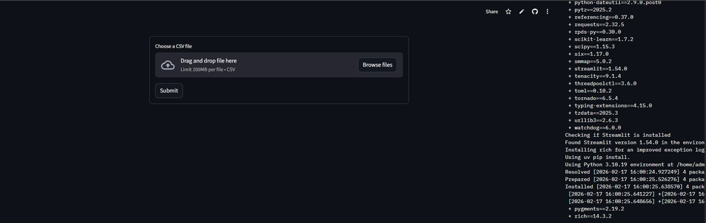

Verifica con datos distintos al desarrollo:

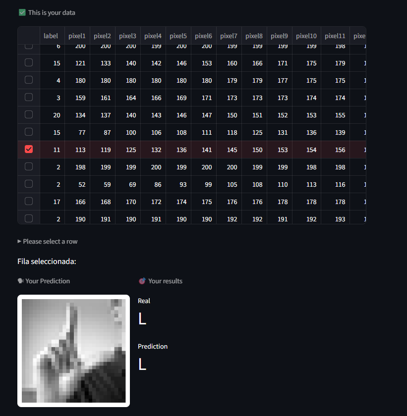

# Cierre

En este notebook viste una posible solución de despliegue usando streamlit en tu repositorio de Github público de streamlit.

Creado por: *Fabián Castellanos*

Revisado por: *Haydemar Nuñez*

Versión de: *Febrero 14, 2026*

*Universidad de los Andes*